# Bayesian Regression: Basic Theory, Analysis, and Application

Author

Samuel Sword

## **Introduction**

Linear regression analysis is often performed under a frequentest approach, relying on repeated sampling methods in order to determine probability statement (Baldwin 2016). In regression with a frequentest approach, model parameters are generally determined using methods such as Ordinary Least Squares (OLS) or Maximum Likelihood Estimate (MLE). While this approach can be effective, another approach to regression (and more generally, statistics as a whole), exists: the Bayesian approach. In Bayesian regression, model parameters are not viewed as fixed values derived using estimation methods, but as probability distributions that can allow for the expression of uncertainty in parameter values (Wundervald 2019). In this report, I aim to examine some of the fundamental ideas underlying the Bayesian approach, analyze it and compare it to the Frequentest approach, and provide an example of creating a Bayesian linear regression model in R.

## **Fundamental Concepts of Bayesian Regression**

### Bayes’ Theorem

Bayesian regression is founded in Bayes’ theorem, which describes the conditional probability of an event given a certain belief about the event or given certain prior information respective to that event. Bayes’ theorem states the following:

$$\begin{aligned}P(A|B)=\dfrac{P(B|A)P(A)}{P(B)}\end{aligned}$$

In the context of Bayesian regression, $P(A)$ is referred to as the *prior probability*, and $P(A|B)$ as the *posterior probability*, due to it’s dependency on event $B$ (Wundervald 2019). Using this theorem, we can proceed to form a linear regression.

### Response and Parameter Distributions

As stated before, Bayes regression is formulated using probability distributions instead of estimated values. Then, for example, with a response sampled from the normal distribution, the Bayesian linear regression model would be:

$$\begin{aligned}y \sim N(\beta^TX, \sigma^2I)\end{aligned}$$

where $y$ is generated from a normal distribution with mean $\beta^T$ (the transposed parameter matrix multiplied by the predictor matrix), and variance $\sigma^2I$

The model parameters are also assumed to have come from a distribution. Given a set of training data, we can calculate the posterior probability of the parameters $\beta$ as:

$$\begin{aligned}P(\beta|data)=\dfrac{P(data|\beta)P(\beta)}{P(data)}\end{aligned}$$

The probability of the data given $\beta$, or $P(data|\beta)$, is referred to as the *likelihood*.

Sometimes a distribution for the priors is known or has been reasonably estimated, in which case that distribution is implemented. Otherwise, non-informative distributions can be used. For regression, the normal distribution is often used (Baldwin 2016).

The denominator, $P(data)$ doesn’t actually need to be specified in most cases. Moreover, the posterior distribution can be shown to be proportional to the likelihood times the prior (McElreath 2016):

$$\begin{aligned}P(\beta|data)\propto P(data|\beta)P(\beta)\end{aligned}$$

### Markov Chain Monte Carlo

In Bayesian regression, the posterior distribution is determined using the given data as well as information regarding the prior. However, often times a posterior doesn’t conform to a known probability distribution. In this case, Markov Chain Monte Carlo methods are used to simulate random draws from the posterior distribution (Baldwin 2016).

## **Analysis of the Bayesian Approach**

As has become apparent, there are some significant differences between the Frequentest approach and the Bayesian approach to regression. Whereas parameters in the frequentest approach are viewed as fixed values and represented by point estimates, the parameters in Bayesian regression are viewed as random variables with probability distributions (Baldwin 2016).

The Bayesian approach also allows for the inclusion of prior information about the parameters. This aspect of the Bayesian model is probably the most important thing about it. As a result, deciding on effective priors for the model is essential, as different priors can lead to completely different model estimations. Furthermore, Bayesian models allow us to quantify the uncertainty in our model, as the result of Bayesian linear regression is a distribution; the more data we have, the less spread out the distribution will be. Furthermore, as data size increases, the effect of the prior on the posterior is mitigated. Thus, it can be seen that as the number of observations used to fit the model approaches infinity, the distribution converges to a single point. That value ends up being the same value as the frequentest derived parameter value (Wundervald 2019).

One well known caveat in Frequentest regression is the negative effect that small amounts of data can have on the performance and reliability of the model. With few observations, there is more uncertainty about the parameters derived in the model, and problems such as over fitting can occur. However, another strength of the Bayesian approach to regression is that it can still perform well even when insufficient data is present because it is influenced by the presence of priors. Similarly to the fact that the priors become less influential as data points increase, inversely, they become more important as data points decrease. It is worth noting that in cases such as this, the model wouldn’t be expected to change much from the priors, since there is little data to influence it. Nonetheless, even in models which have very low numbers of data points, a model formulated using the Bayesian approach is generally going to be more reliable than a model using the Frequentest approach (Wundervald 2019).

## **Application**

For this application, a Bayesian linear regression will be made using Boston Housing data. To form the Bayesian LR, the *rstanarm* package is used. The following R code is based off of a tutorial from rpubs.com.

```r
suppressPackageStartupMessages(library(mlbench))
suppressPackageStartupMessages(library(rstanarm))
suppressPackageStartupMessages(library(bayestestR))
suppressPackageStartupMessages(library(bayesplot))
suppressPackageStartupMessages(library(insight))
suppressPackageStartupMessages(library(broom))
data("BostonHousing")
str(BostonHousing)
```

```
'data.frame':   506 obs. of  14 variables:
 $ crim   : num  0.00632 0.02731 0.02729 0.03237 0.06905 ...
 $ zn     : num  18 0 0 0 0 0 12.5 12.5 12.5 12.5 ...
 $ indus  : num  2.31 7.07 7.07 2.18 2.18 2.18 7.87 7.87 7.87 7.87 ...
 $ chas   : Factor w/ 2 levels "0","1": 1 1 1 1 1 1 1 1 1 1 ...
 $ nox    : num  0.538 0.469 0.469 0.458 0.458 0.458 0.524 0.524 0.524 0.524 ...
 $ rm     : num  6.58 6.42 7.18 7 7.15 ...
 $ age    : num  65.2 78.9 61.1 45.8 54.2 58.7 66.6 96.1 100 85.9 ...
 $ dis    : num  4.09 4.97 4.97 6.06 6.06 ...
 $ rad    : num  1 2 2 3 3 3 5 5 5 5 ...
 $ tax    : num  296 242 242 222 222 222 311 311 311 311 ...
 $ ptratio: num  15.3 17.8 17.8 18.7 18.7 18.7 15.2 15.2 15.2 15.2 ...
 $ b      : num  397 397 393 395 397 ...
 $ lstat  : num  4.98 9.14 4.03 2.94 5.33 ...
 $ medv   : num  24 21.6 34.7 33.4 36.2 28.7 22.9 27.1 16.5 18.9 ...
```

### OLS Model

Firstly, only three of the variables will be used in order to simplify the process. We’ll use two numeric variables `age` and `dis`, and one categorical variables `chas`. Our response will be `medv` (the median value of owners’ homes.)

```r
bost_simplified <- BostonHousing[,c("medv","age","dis","chas")]
head(bost_simplified)
```

```
  medv  age    dis chas
1 24.0 65.2 4.0900    0
2 21.6 78.9 4.9671    0
3 34.7 61.1 4.9671    0
4 33.4 45.8 6.0622    0
5 36.2 54.2 6.0622    0
6 28.7 58.7 6.0622    0
```

Let’s first view a model formed using OLS:

```r
frequentest_model<-lm(medv~., data=bost_simplified)
tidy(frequentest_model)
```

```
# A tibble: 4 × 5
  term        estimate std.error statistic  p.value
  <chr>          <dbl>     <dbl>     <dbl>    <dbl>
1 (Intercept)   32.7      2.25      14.6   2.33e-40
2 age           -0.143    0.0198    -7.21  2.09e-12
3 dis           -0.246    0.265     -0.928 3.54e- 1
4 chas1          7.51     1.46       5.13  4.16e- 7
```

We can see that that `dis` is statistically insignificant according to the OLS model. It will be interesting to see if we find the same insight when we fit the Bayesian LR model.

### Bayesian Model

The syntax for fitting a Bayesian model using the *stan_glm* function is nearly identical to that of the *lm* function.

```r
bayes_model <- stan_glm(medv~., data=bost_simplified)
```

```r
print(bayes_model, digits = 3)
```

```
stan_glm
 family:       gaussian [identity]
 formula:      medv ~ .
 observations: 506
 predictors:   4
------
            Median MAD_SD
(Intercept) 32.756  2.266
age         -0.143  0.020
dis         -0.244  0.267
chas1        7.561  1.529

Auxiliary parameter(s):
      Median MAD_SD
sigma 8.331  0.255

------
* For help interpreting the printed output see ?print.stanreg
* For info on the priors used see ?prior_summary.stanreg
```

The computed median for each parameter are the medians found from the MCMC simulations, and `MAD_SD` is the median absolute deviation from the MCMC simulations as well. `MAD_SD` is used instead of standard deviation because it is more robust to long-tailed distributions.

#### MCMC visualizations

Let’s visualize the MCMC simulations for each predictor:

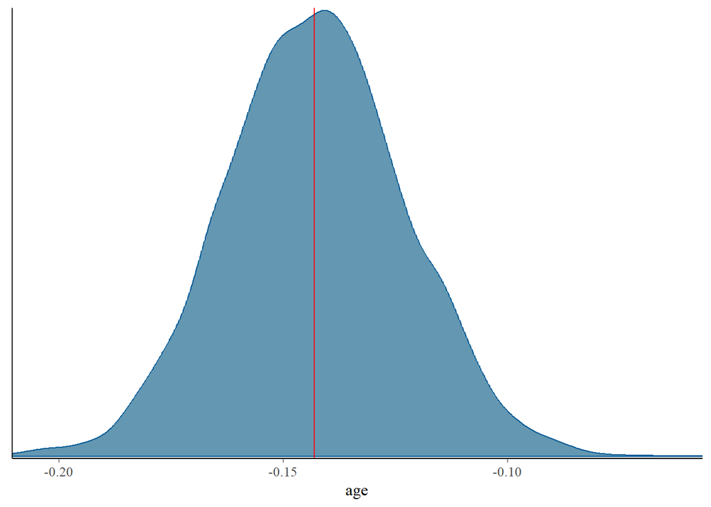

```r
mcmc_dens(bayes_model, pars = c("age"))+
  vline_at(-0.143, col="red")
```

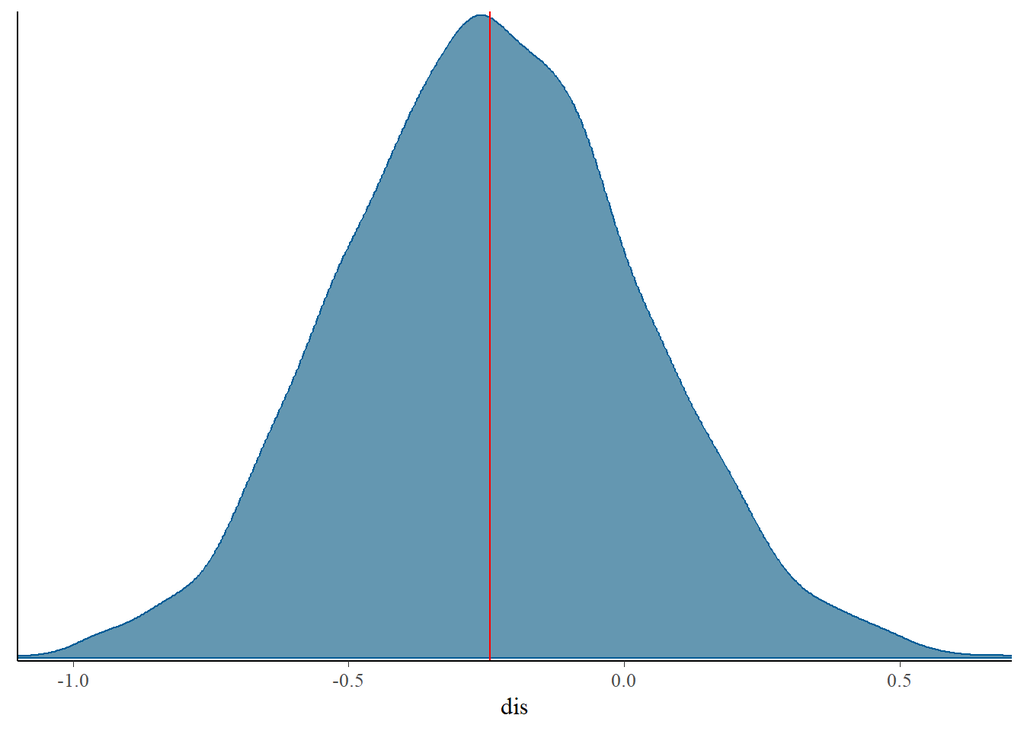

```r
mcmc_dens(bayes_model, pars = c("dis"))+
  vline_at(-0.243, col="red")
```

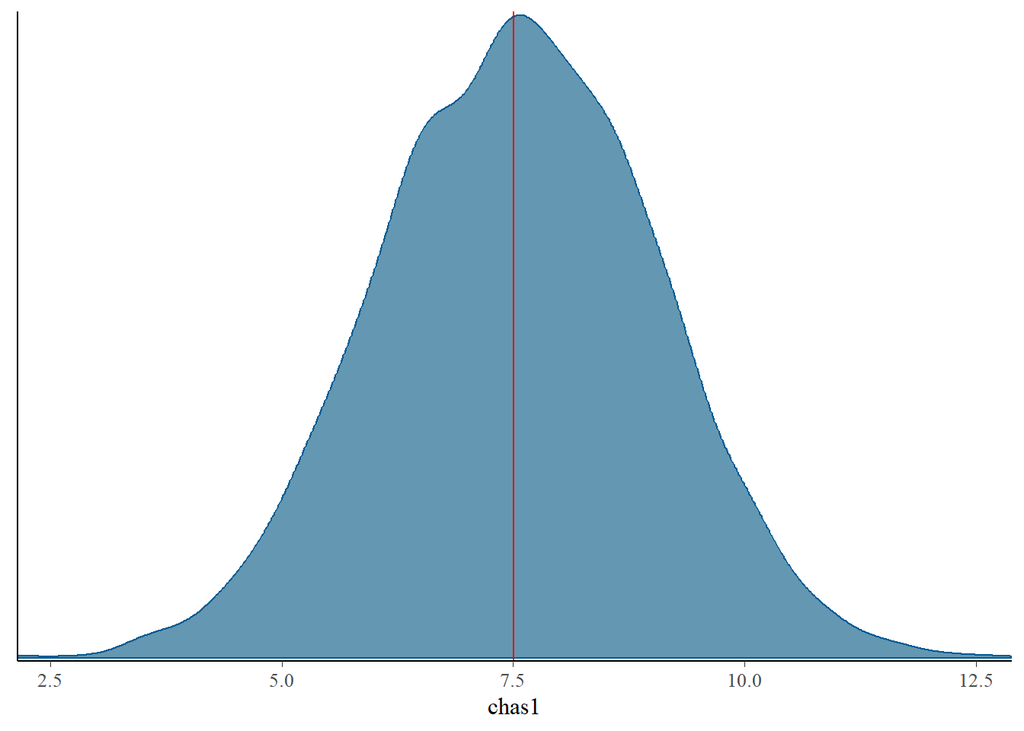

```r
mcmc_dens(bayes_model, pars = c("chas1"))+
  vline_at(7.502, col="red")
```

As we can see, the `Median` calculation in the summary of `bayes_model` is the median calculated from the MCMC simulations. As such, we can see that this is how point estimates for Bayesian models are formed. Even though the Bayesian approach is focused on the probability distributions of parameters instead of their specific values, we can still obtain specific estimates based on the distributions.

### Model Evaluation

We can use the *describe_posterior* function from the *bayestestR* package to analyze the model we have.

```r
describe_posterior(bayes_model)
```

```
Summary of Posterior Distribution

Parameter   | Median |         95% CI |     pd |          ROPE | % in ROPE |  Rhat |     ESS
--------------------------------------------------------------------------------------------
(Intercept) |  32.76 | [28.16, 37.12] |   100% | [-0.92, 0.92] |        0% | 1.000 | 2277.00
age         |  -0.14 | [-0.18, -0.10] |   100% | [-0.92, 0.92] |      100% | 1.000 | 2396.00
dis         |  -0.24 | [-0.76,  0.30] | 81.83% | [-0.92, 0.92] |      100% | 0.999 | 2500.00
chas1       |   7.56 | [ 4.63, 10.38] |   100% | [-0.92, 0.92] |        0% | 1.000 | 3634.00
```

We get some important statistics here:

```r
confint(frequentest_model)
```

```
                 2.5 %     97.5 %
(Intercept) 28.3250180 37.1545648
age         -0.1817211 -0.1038781
dis         -0.7670750  0.2747543
chas1        4.6353593 10.3905831
```

- `pd`: Probability of Direction. This is the probability that the parameter is of the same sign (+/-) as the calculated median. A high pd is good. This is generally considered to be the best equivalent for the p-value.
- `ESS`: effective sample size. it captures how many independent draws contain the same amount of information as the dependent sample obtained by the MCMC algorithm, the higher the ESS the better. The threshold used in practice is 400.

If the posterior paramaters are distributed in a normal-like manner, we would expect their central statistics to be similar. Let’s check the mean, median, and Maximum A posteriori (MAP) of each parameter to if this is the case:

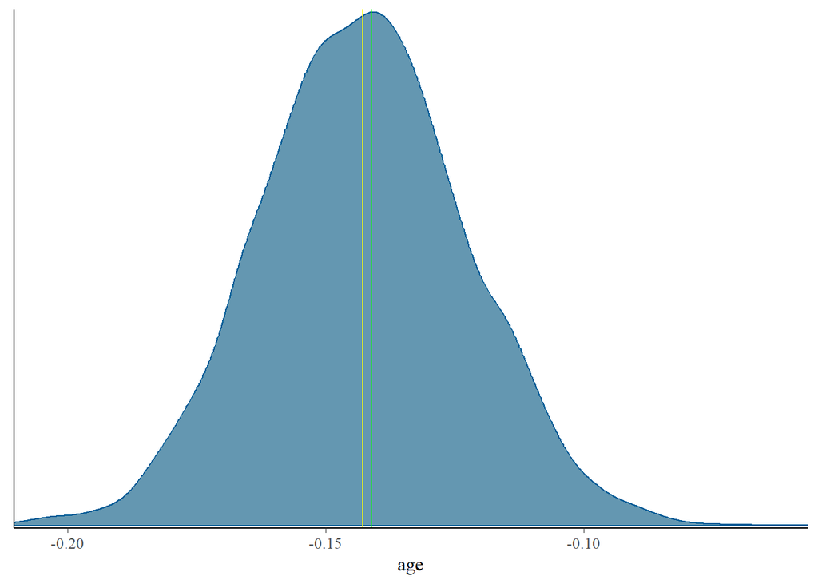

```r
post_params <- get_parameters(bayes_model)

mcmc_dens(bayes_model, pars=c("age"))+
  vline_at(median(post_params$age), col="red")+
  vline_at(mean(post_params$age), col="yellow")+
  vline_at(map_estimate(post_params$age), col="green")
```

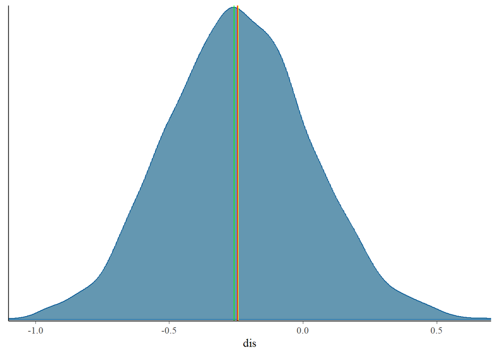

```r
mcmc_dens(bayes_model, pars=c("dis"))+
  vline_at(median(post_params$dis), col="red")+
  vline_at(mean(post_params$dis), col="yellow")+
  vline_at(map_estimate(post_params$dis), col="green")
```

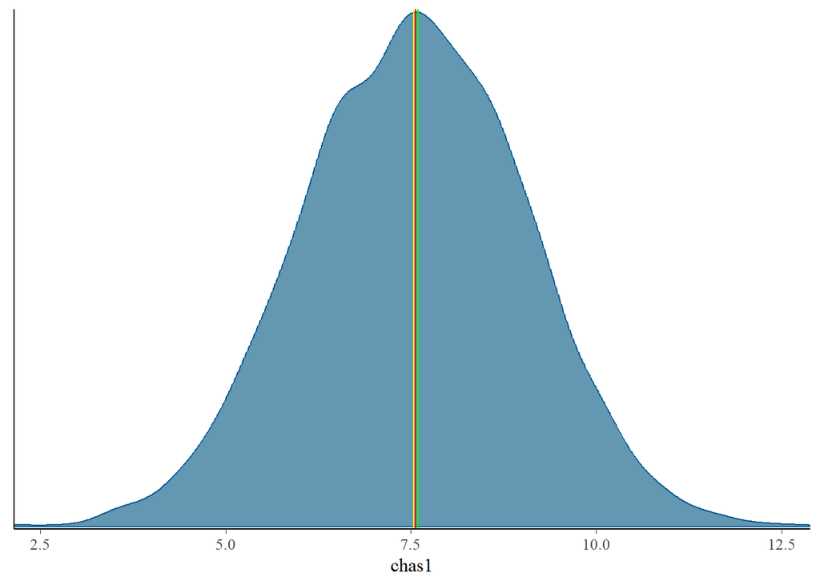

```r
mcmc_dens(bayes_model, pars=c("chas1"))+
  vline_at(median(post_params$chas1), col="red")+
  vline_at(mean(post_params$chas1), col="yellow")+
  vline_at(map_estimate(post_params$chas1), col="green")
```

They all seem to be normally (or normally-like) distributed.

### Inference

In the same manner as the Frequentest approach, we can use some of the statistics produced by the model to infer on the significance of specific parameters.

```r
hdi(bayes_model)
```

```
Highest Density Interval

Parameter   |        95% HDI
----------------------------
(Intercept) | [27.95, 36.84]
age         | [-0.18, -0.10]
dis         | [-0.74,  0.31]
chas1       | [ 4.63, 10.38]
```

```r
eti(bayes_model)
```

```
Equal-Tailed Interval

Parameter   |        95% ETI | Effects |   Component
----------------------------------------------------
(Intercept) | [28.16, 37.12] |   fixed | conditional
age         | [-0.18, -0.10] |   fixed | conditional
dis         | [-0.76,  0.30] |   fixed | conditional
chas1       | [ 4.63, 10.38] |   fixed | conditional
```

The above functions produce the Highest Density Interval and Equal-Tailed Interval, respectively. As mentioned above, those are the two methods used in computing the credible interval. We can see that the intervals for `dis` both contain 0, suggesting that `dis` is statistically insignificant.

Furthermore, we can use the *rope* function to test the probability that a parameter falls within the Region of Practical Equivalence. If has a high probability, we can assume it to be insignificant.

```r
rope(post_params$age)
```

```
# Proportion of samples inside the ROPE [-0.10, 0.10]:

inside ROPE
-----------
0.00 %
```

```r
rope(post_params$dis)
```

```
# Proportion of samples inside the ROPE [-0.10, 0.10]:

inside ROPE
-----------
20.21 %
```

```r
rope(post_params$chas1)
```

```
# Proportion of samples inside the ROPE [-0.10, 0.10]:

inside ROPE
-----------
0.00 %
```

`dis` has around around a 20-21% (the specific value changes based on each iteration of the MCMC iteration) chance of falling within the ROPE, suggesting it to be insignificant.

```r
shapiro.test(frequentest_model$residuals)
```

```
    Shapiro-Wilk normality test

data:  frequentest_model$residuals
W = 0.86408, p-value < 2.2e-16
```

### Computational Differences

```r
start.time <- Sys.time()

frequentest_model<-lm(medv~., data=bost_simplified)

end.time <- Sys.time()
time.taken_freq <- round(end.time - start.time,2)
```

```r
start.time <- Sys.time()

bayes_model <- stan_glm(medv~., data=bost_simplified)
end.time <- Sys.time()
time.taken_bayes <- round(end.time - start.time,2)
```

```r
time.taken_freq
```

```
Time difference of 0 secs
```

```r
time.taken_bayes
```

```
Time difference of 1.27 secs
```

We can see that the OLS model is significantly more efficient than the Bayes model, likely because the Bayes undergoes the MCMC iterations. With larger data sets (this one has only 506 observations) or more complicated models, the OLS model could prove to have significant advantages over the Bayes model in terms of efficiency. Thus, in a situation similar to this where the two models produce similar results and we don’t have a preference of one over the other, I would suggest using a Frequentest model over a Bayes model.

## **References**

Baldwin, S. A., & Larson, M. J. (2017). An introduction to using Bayesian linear regression with clinical data. Behaviour research and therapy, 98, 58–75. https://doi.org/10.1016/j.brat.2016.12.016

Liu, C. (2020). Bayesian linear regression. RPubs. https://rpubs.com/Qsheep/BayesianLinearRegression

McElreath, R. (2016). Statistical Rethinking: A Bayesian Course with Examples in R and Stan (1st ed.). Chapman and Hall/CRC. https://doi.org/10.1201/9781315372495

Smith, A. F. M. (1973). A General Bayesian Linear Model. Journal of the Royal Statistical Society. Series B (Methodological), 35(1), 67–75. http://www.jstor.org/stable/2985129

Wundervald, Bruna. (2019). Bayesian Linear Regression. 10.13140/RG.2.2.28385.97121.